# Modelo Elastic Net

Maestria en Matemáticas Aplicadas y Ciencias de la Computación

Jorge Esneider Henao

Diego Alberto Rodríguez Cruz Hector Leandro Rojas

2023-06-09

# Dependencias

- ´install.packages(“lasso2”)´
- ´install.packages(“tidyverse”)´
- ´install.packages(“FSelectorRcpp”)´
- ´install.packages(“tibble”)´
- ´install.packages(“mlr”)´
- ´install.packages(“parallel”)´
- ´install.packages(“parallelMap”)´
- ´install.packages(“kknn”)´
- ´install.packages(“Formula”)´
- ´install.packages(“plotrix”)´
- ´install.packages(“TeachingDemos”)´
- ´install.packages(“plotmo”)´
- ´install.packages(“corrplot”)´
- ´install.packages(“glmnet”)´

# Librerías

[output not shown]

[output not shown]

# Variable(s) Global(es)

```r
#Definicion del valor de la semilla global
semilla <- 123
set.seed(semilla)
```

# Dataset(s) aplicando Elastic Net

- Energy Effiency
- Boston Housing
- CO2
- Iowa

# Energy Effiency

Dataset (Conjunto de datos) tomado de https://archive.ics.uci.edu/dataset/242/energy+efficiency. Este estudio analizó la evaluación de los requisitos de carga de calefacción y refrigeración de los edificios (es decir, la eficiencia energética) en función de los parámetros del edificio. El conjunto de datos comprende 768 muestras y 8 características

| Variable | Descripción |
| --- | --- |
| X1 | Relative Compactness |
| X2 | Surface Area |
| X3 | Wall Area |
| X4 | Roof Area |
| X5 | Overall Height |
| X6 | Orientation |
| X7 | Glazing Area |
| X8 | Glazing Area Distribution |
| y1 | Heating Load |
| y2 | Cooling Load |

```r
set.seed(semilla)

#Carga de datos
orig <- read.delim2(file="ENB2012_data.csv", header=TRUE, sep = ",", dec = ".")

#solo se va tomar la variable Y1, por ende se elimina Y2
data <- orig[, -which(names(orig) == "Y2")]
```

```r
set.seed(semilla)

# Visualizacion de datos cargados
head(data)
```

```
##     X1    X2    X3     X4 X5 X6 X7 X8    Y1
## 1 0.98 514.5 294.0 110.25  7  2  0  0 15.55
## 2 0.98 514.5 294.0 110.25  7  3  0  0 15.55
## 3 0.98 514.5 294.0 110.25  7  4  0  0 15.55
## 4 0.98 514.5 294.0 110.25  7  5  0  0 15.55
## 5 0.90 563.5 318.5 122.50  7  2  0  0 20.84
## 6 0.90 563.5 318.5 122.50  7  3  0  0 21.46
```

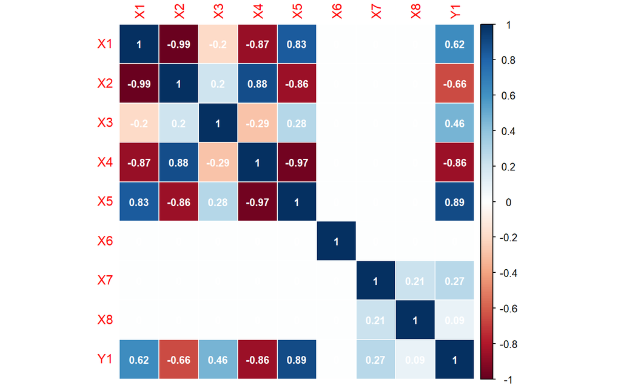

```r
set.seed(semilla)

# Correlación entre las variables númericas
mat_cor <- data %>% cor(method="pearson") %>% round(digits=2)

# Mapa de calor de la correlación
corrplot(mat_cor,
         method = "color",
         addgrid.col = 'white',
         number.cex = 0.8,
         addCoef.col = "white"
         )
```

```r
set.seed(semilla)

# Cantidad de Nulos/Vacios en el dataset
sum(is.na(data))
```

```
## [1] 0
```

```r
set.seed(semilla)

#Ubicacion de los valores nulos en las columnas
sapply(data, function(x)sum(is.na(x)))
```

```
## X1 X2 X3 X4 X5 X6 X7 X8 Y1
##  0  0  0  0  0  0  0  0  0
```

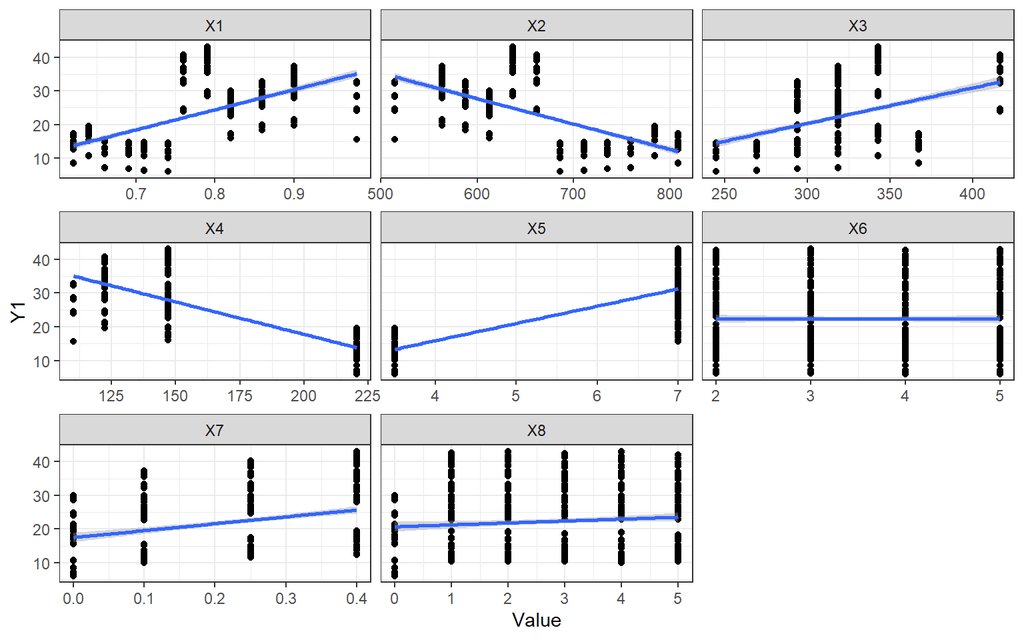

```r
set.seed(semilla)

dataGather <- gather(data, "Variable", "Value", -Y1)
ggplot(dataGather, aes(Value, Y1)) +
  facet_wrap(~ Variable, scales = "free_x") +
  geom_point() +
  geom_smooth(method = "lm") +
  theme_bw()
```

```r
  #theme(axis.text.x = element_text(angle = 90))
```

## Ridge

```r
set.seed(semilla)

dataTask <- makeRegrTask(data = data, target = "Y1")
ridge <- makeLearner("regr.glmnet", alpha = 0, id = "ridge")
```

### Visualización de Datos Filtrados

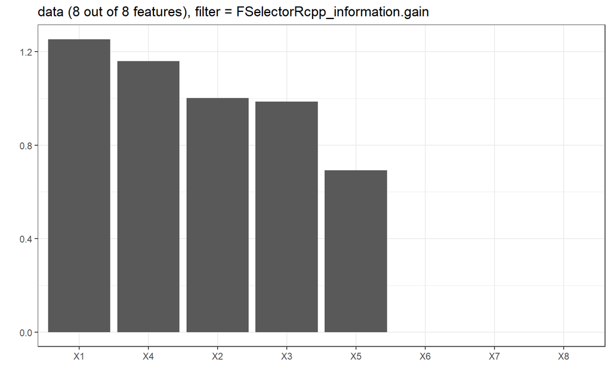

```r
set.seed(semilla)

filterVals <- generateFilterValuesData(dataTask)
plotFilterValues(filterVals) +
  theme_bw()
```

### Mejorando hiperparámetros lambda (s)

```r
set.seed(semilla)

ridgeParamSpace <- makeParamSet(
  makeNumericParam("s", lower = 0, upper = 15))

randSearch <- makeTuneControlRandom(maxit = 200)
cvForTuning <- makeResampleDesc("RepCV", folds = 3, reps = 10)


parallelStartSocket(cpus = detectCores())
```

```
## Starting parallelization in mode=socket with cpus=4.
```

```r
tunedRidgePars <- tuneParams(ridge, task = dataTask,
                             resampling = cvForTuning,
                             par.set = ridgeParamSpace,
                             control = randSearch)
```

```
## [Tune] Started tuning learner ridge for parameter set:
```

```
##      Type len Def  Constr Req Tunable Trafo
## s numeric   -   - 0 to 15   -    TRUE     -
```

```
## With control class: TuneControlRandom
```

```
## Imputation value: Inf
```

```
## Exporting objects to slaves for mode socket: .mlr.slave.options
```

```
## Mapping in parallel: mode = socket; level = mlr.tuneParams; cpus = 4; elements = 200.
```

```
## [Tune] Result: s=0.37 : mse.test.mean=10.3130513
```

```r
parallelStop()
```

```
## Stopped parallelization. All cleaned up.
```

```r
tunedRidgePars
```

```
## Tune result:
## Op. pars: s=0.37
## mse.test.mean=10.3130513
```

### Visualización de los hiperparametros ajustados

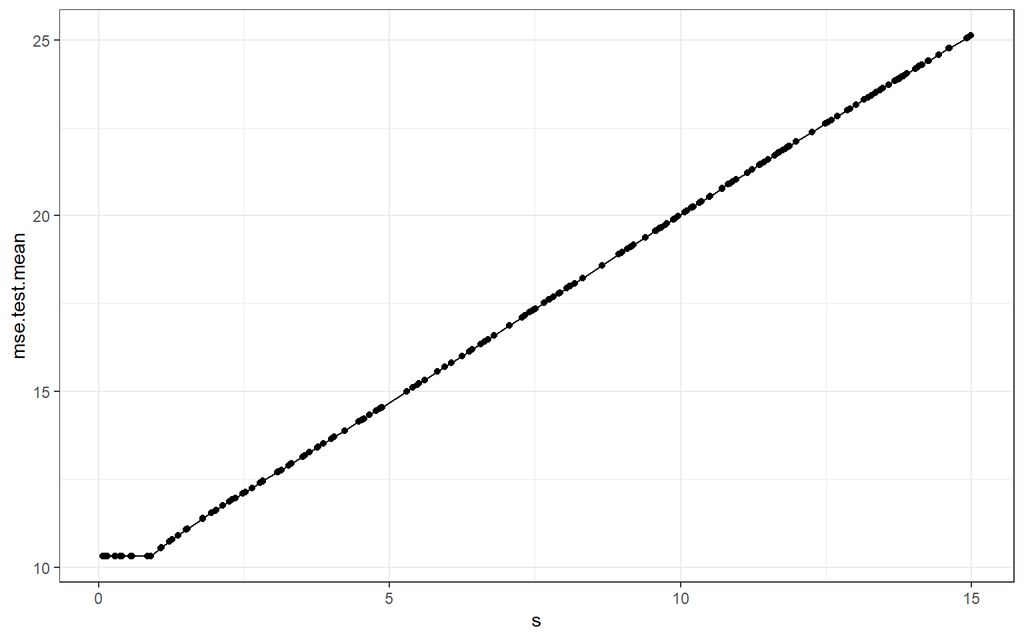

```r
set.seed(semilla)

ridgeTuningData <- generateHyperParsEffectData(tunedRidgePars)
plotHyperParsEffect(ridgeTuningData,
                    x = "s",
                    y = "mse.test.mean",
                    plot.type = "line") +
  theme_bw()
```

### Entrenamiento con Ridge usando los parametros de lambda ajustados

```r
set.seed(semilla)

tunedRidge <- setHyperPars(ridge, par.vals = tunedRidgePars$x)
tunedRidgeModel <- train(tunedRidge, dataTask)
```

### Coeficientes del modelo

```r
set.seed(semilla)

ridgeModelData <- getLearnerModel(tunedRidgeModel)
ridgeCoefs <- coef(ridgeModelData, s = tunedRidgePars$x$s)
ridgeCoefs
```

```
## 9 x 1 sparse Matrix of class "dgCMatrix"
##                      s1
## (Intercept)  6.67210018
## X1          -4.85066898
## X2          -0.01338660
## X3           0.05554822
## X4          -0.05172201
## X5           2.84995915
## X6          -0.02142272
## X7          18.27926796
## X8           0.21490299
```

### Visualización de coeficientes

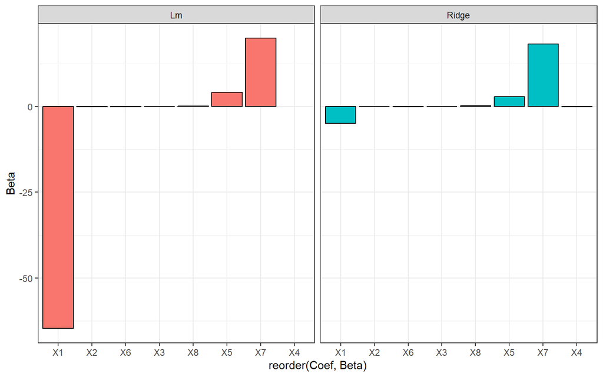

```r
set.seed(semilla)

lmCoefs <- coef(lm(Y1 ~ ., data = data))

coefTib <- tibble(Coef = rownames(ridgeCoefs)[-1],
                  Ridge = as.vector(ridgeCoefs)[-1],
                  Lm = as.vector(lmCoefs)[-1]
)

coefUntidy <- gather(coefTib, key = Model, value = Beta, -Coef)
ggplot(coefUntidy, aes(reorder(Coef, Beta), Beta, fill = Model)) +
  geom_bar(stat = "identity", col = "black") +
  facet_wrap(~Model) +
  theme_bw() +
  theme(legend.position = "none")
```

## LASSO

```r
set.seed(semilla)

lasso <- makeLearner("regr.glmnet", alpha = 1, id = "lasso")
```

### Ajuste de parámetros lambda de LASSO

```r
set.seed(semilla)

lassoParamSpace <- makeParamSet(
makeNumericParam("s", lower = 0, upper = 15))
parallelStartSocket(cpus = detectCores())
```

```
## Starting parallelization in mode=socket with cpus=4.
```

```r
tunedLassoPars <- tuneParams(lasso, task = dataTask,
resampling = cvForTuning,
par.set = lassoParamSpace,
control = randSearch)
```

```
## [Tune] Started tuning learner lasso for parameter set:
```

```
##      Type len Def  Constr Req Tunable Trafo
## s numeric   -   - 0 to 15   -    TRUE     -
```

```
## With control class: TuneControlRandom
```

```
## Imputation value: Inf
```

```
## Exporting objects to slaves for mode socket: .mlr.slave.options
```

```
## Mapping in parallel: mode = socket; level = mlr.tuneParams; cpus = 4; elements = 200.
```

```
## [Tune] Result: s=0.0673 : mse.test.mean=9.1186963
```

```r
parallelStop()
```

```
## Stopped parallelization. All cleaned up.
```

```r
tunedLassoPars
```

```
## Tune result:
## Op. pars: s=0.0673
## mse.test.mean=9.1186963
```

### Visualización de hiperparametros ajustados

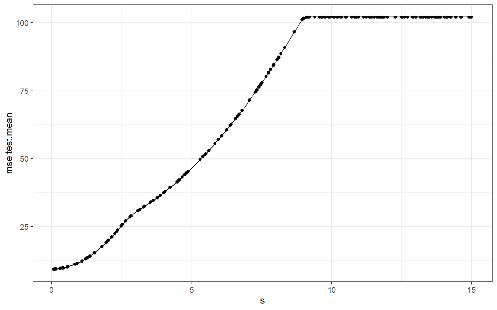

```r
set.seed(semilla)

lassoTuningData <- generateHyperParsEffectData(tunedLassoPars)
plotHyperParsEffect(lassoTuningData,
                    x = "s",
                    y = "mse.test.mean",
                    plot.type = "line") +
  theme_bw()
```

### Entrenamiento con LASSO usando los parametros de lambda ajustados

```r
set.seed(semilla)

tunedLasso <- setHyperPars(lasso, par.vals = tunedLassoPars$x)
tunedLassoModel <- train(tunedLasso, dataTask)
```

### Coeficientes del modelo LASSO

```r
set.seed(semilla)

lassoModelData <- getLearnerModel(tunedLassoModel)
lassoCoefs <- coef(lassoModelData, s = tunedLassoPars$x$s)
lassoCoefs
```

```
## 9 x 1 sparse Matrix of class "dgCMatrix"
##                       s1
## (Intercept) -19.11910537
## X1           -5.51050630
## X2            .
## X3            0.04415403
## X4            .
## X5            5.05292568
## X6            .
## X7           19.51563341
## X8            0.16794930
```

### Visualización de parametros

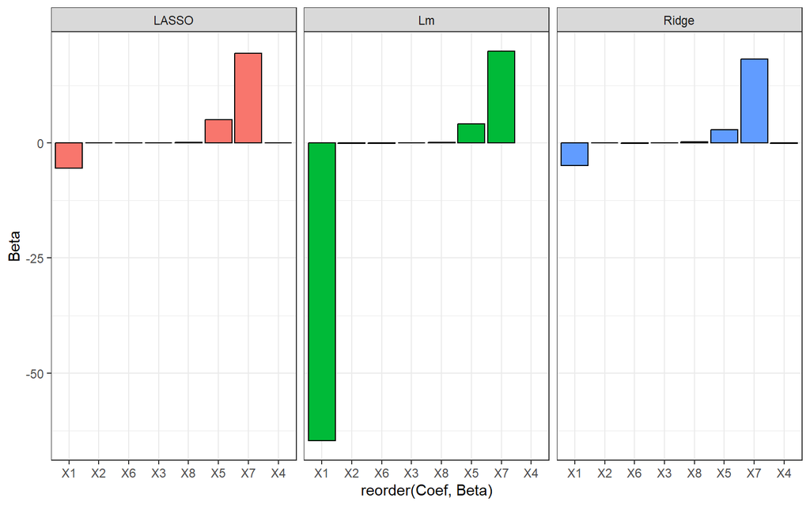

```r
set.seed(semilla)

coefTib$LASSO <- as.vector(lassoCoefs)[-1]
coefUntidy <- gather(coefTib, key = Model, value = Beta, -Coef)

ggplot(coefUntidy, aes(reorder(Coef, Beta), Beta, fill = Model)) +
  geom_bar(stat = "identity", col = "black") +
  facet_wrap(~ Model) +
  theme_bw() +
  theme(legend.position = "none")
```

## Elastic Net

```r
set.seed(semilla)

# Modelo Entrenamiento Elastic Net
elastic <- makeLearner("regr.glmnet", id = "elastic")
```

### Ajuste de lambda y alpha

```r
set.seed(semilla)

elasticParamSpace <- makeParamSet(
makeNumericParam("s", lower = 0, upper = 10),
makeNumericParam("alpha", lower = 0, upper = 1))

randSearchElastic <- makeTuneControlRandom(maxit = 400)
parallelStartSocket(cpus = detectCores())
```

```
## Starting parallelization in mode=socket with cpus=4.
```

```r
tunedElasticPars <- tuneParams(elastic, task = dataTask,
                               resampling = cvForTuning,
                               par.set = elasticParamSpace,
                               control = randSearchElastic)
```

```
## [Tune] Started tuning learner elastic for parameter set:
```

```
##          Type len Def  Constr Req Tunable Trafo
## s     numeric   -   - 0 to 10   -    TRUE     -
## alpha numeric   -   -  0 to 1   -    TRUE     -
```

```
## With control class: TuneControlRandom
```

```
## Imputation value: Inf
```

```
## Exporting objects to slaves for mode socket: .mlr.slave.options
```

```
## Mapping in parallel: mode = socket; level = mlr.tuneParams; cpus = 4; elements = 400.
```

```
## [Tune] Result: s=0.0587; alpha=0.108 : mse.test.mean=8.8406990
```

```r
parallelStop()
```

```
## Stopped parallelization. All cleaned up.
```

```r
tunedElasticPars
```

```
## Tune result:
## Op. pars: s=0.0587; alpha=0.108
## mse.test.mean=8.8406990
```

### Visualización de parametros ajustados

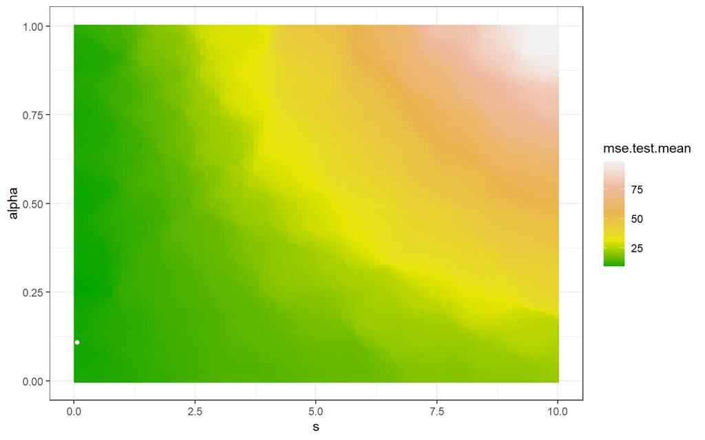

### Entrenamiento con hiperparametros ajustados

```r
set.seed(semilla)

tunedElastic <- setHyperPars(elastic, par.vals = tunedElasticPars$x)
tunedElasticModel <- train(tunedElastic, dataTask)
```

## Coeficientes de los modelos

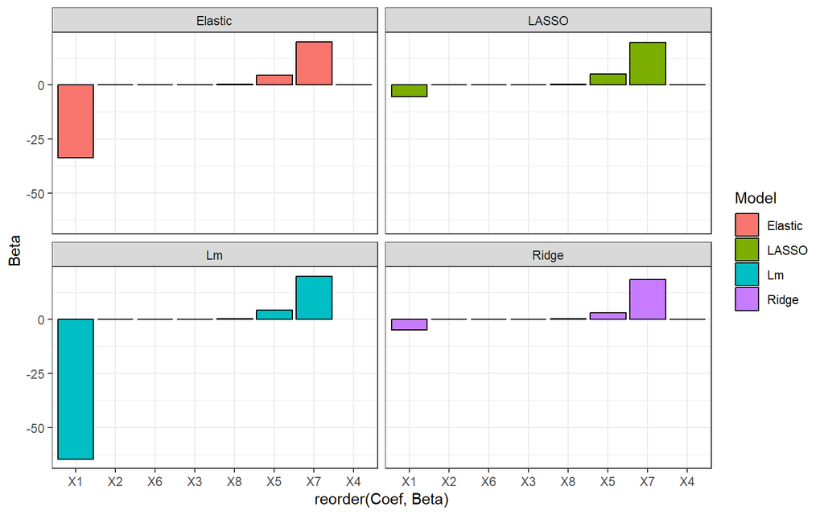

```r
set.seed(semilla)

elasticModelData <- getLearnerModel(tunedElasticModel)
elasticCoefs <- coef(elasticModelData, s = tunedElasticPars$x$s)
coefTib$Elastic <- as.vector(elasticCoefs)[-1]

coefUntidy <- gather(coefTib, key = Model, value = Beta, -Coef)
ggplot(coefUntidy, aes(reorder(Coef, Beta), Beta, fill = Model)) +
  geom_bar(stat = "identity", position = "dodge", col = "black") +
  facet_wrap(~ Model) +
  theme_bw()
```

```r
set.seed(semilla)

ridgeWrapper <- makeTuneWrapper(ridge, resampling = cvForTuning,
par.set = ridgeParamSpace,
control = randSearch)
lassoWrapper <- makeTuneWrapper(lasso,
                                resampling = cvForTuning,
                                par.set = lassoParamSpace,
                                control = randSearch)
elasticWrapper <- makeTuneWrapper(elastic,
                                  resampling = cvForTuning,
                                  par.set = elasticParamSpace,
                                  control = randSearchElastic)
learners = list(ridgeWrapper, lassoWrapper, elasticWrapper, "regr.lm")
```

## Valores de los modelos

```r
set.seed(semilla)

kFold3 <- makeResampleDesc("CV", iters = 3)
parallelStartSocket(cpus = detectCores())
```

```
## Starting parallelization in mode=socket with cpus=4.
```

```r
bench <- benchmark(learners, dataTask, kFold3)
```

```
## Exporting objects to slaves for mode socket: .mlr.slave.options
```

```
## Mapping in parallel: mode = socket; level = mlr.benchmark; cpus = 4; elements = 4.
```

```r
parallelStop()
```

```
## Stopped parallelization. All cleaned up.
```

```r
bench
```

```
##   task.id    learner.id mse.test.mean
## 1    data   ridge.tuned     10.216423
## 2    data   lasso.tuned      9.043327
## 3    data elastic.tuned      8.674381
## 4    data       regr.lm      8.648446
```

## Grafica de modelos

- Ridge

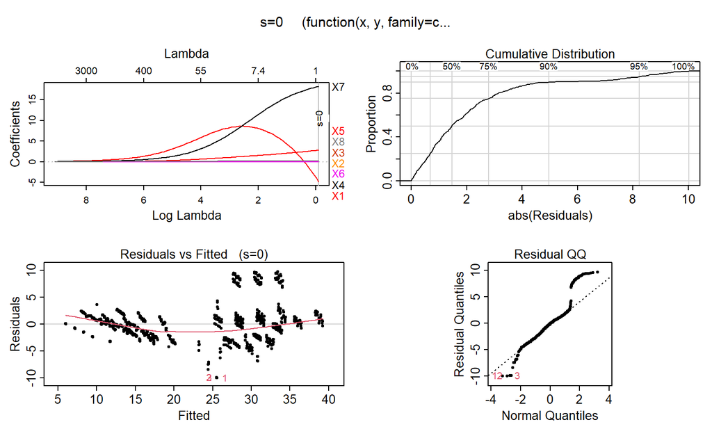

```r
set.seed(semilla)

start_time <- Sys.time()  # Registra el tiempo de inicio
plotres(ridgeModelData)
```

```r
end_time <- Sys.time()  # Registra el tiempo de finalización
execution_time <- end_time - start_time  # Calcula el tiempo de ejecución
print(execution_time)  # Imprime el tiempo de ejecución
```

```
## Time difference of 0.9617279 secs
```

- Lasso

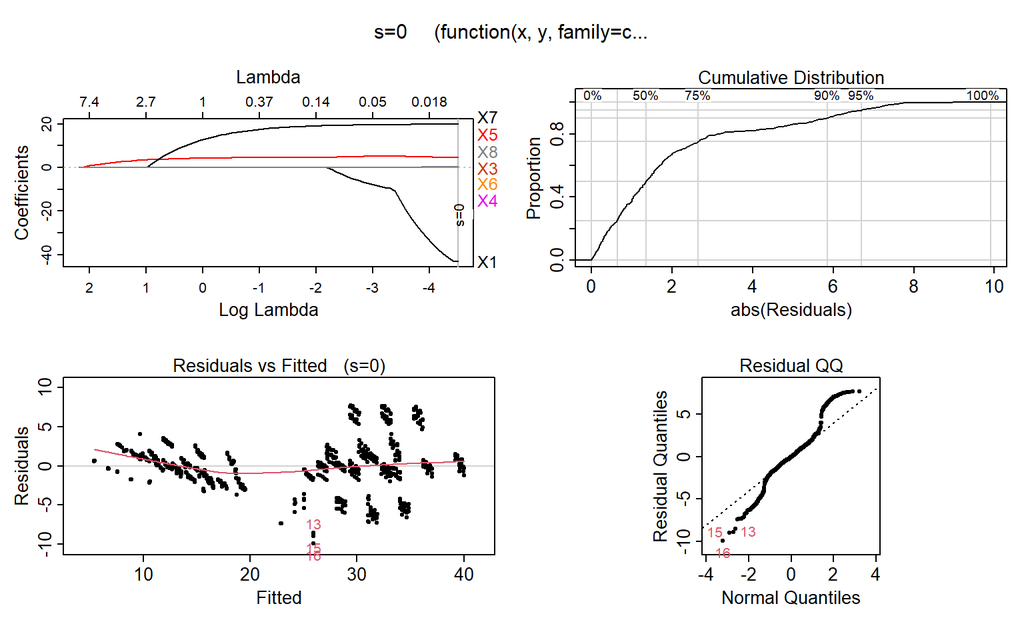

```r
set.seed(semilla)

start_time <- Sys.time()  # Registra el tiempo de inicio
plotres(lassoModelData)
```

```r
end_time <- Sys.time()  # Registra el tiempo de finalización
execution_time <- end_time - start_time  # Calcula el tiempo de ejecución
print(execution_time)  # Imprime el tiempo de ejecución
```

```
## Time difference of 0.8080289 secs
```

- Elastic Net

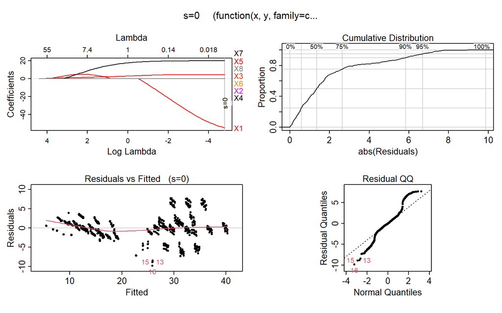

```r
set.seed(semilla)

start_time <- Sys.time()  # Registra el tiempo de inicio
plotres(elasticModelData)
```

```r
end_time <- Sys.time()  # Registra el tiempo de finalización
execution_time <- end_time - start_time  # Calcula el tiempo de ejecución
print(execution_time)  # Imprime el tiempo de ejecución
```

```
## Time difference of 0.7508302 secs
```

# Boston Housing

| variable | Descripción |
| --- | --- |
| crim | Crimen per cápita por ciudad |
| zn | proporción de terrenos residenciales divididos en zonas para lotes de más de 25,000 pies cuadrados |
| indus | proporción de acres de negocios no minoristas por ciudad |
| chas | variable ficticia de Charles River (= 1 si el tramo limita el río, 0 de lo contrario) |
| nox | concentración de óxidos nítricos (partes por 10 millones) |
| rm | número promedio de habitaciones por vivienda |
| age | proporción de unidades ocupadas por sus propietarios construidas antes de 1940 |
| dis | Los datos de la vivienda contienen 506 secciones censales de Boston del censo de 1970. |
| rad | índice de accesibilidad a las autopistas radiales |
| tax | tasa de impuesto a la propiedad de valor completo por USD 10,000 |
| ptratio | tasa de impuesto a la propiedad de valor completo por USD 10,000 |
| b | 1000 (B - 0,63)^ 2, donde B es la proporción de negros por ciudad |
| lstat | porcentaje de estado inferior de la población |
| medv | valor mediano de las viviendas ocupadas por sus propietarios en USD 1000 |

```r
set.seed(semilla)

# Importar datos desde un archivo CSV en una URL
url <- "https://raw.githubusercontent.com/selva86/datasets/master/BostonHousing.csv"
datos <- read.csv(url)
```

```r
set.seed(semilla)

# Visualizacion de datos cargados
head(datos)
```

```
##      crim zn indus chas   nox    rm  age    dis rad tax ptratio      b lstat
## 1 0.00632 18  2.31    0 0.538 6.575 65.2 4.0900   1 296    15.3 396.90  4.98
## 2 0.02731  0  7.07    0 0.469 6.421 78.9 4.9671   2 242    17.8 396.90  9.14
## 3 0.02729  0  7.07    0 0.469 7.185 61.1 4.9671   2 242    17.8 392.83  4.03
## 4 0.03237  0  2.18    0 0.458 6.998 45.8 6.0622   3 222    18.7 394.63  2.94
## 5 0.06905  0  2.18    0 0.458 7.147 54.2 6.0622   3 222    18.7 396.90  5.33
## 6 0.02985  0  2.18    0 0.458 6.430 58.7 6.0622   3 222    18.7 394.12  5.21
##   medv
## 1 24.0
## 2 21.6
## 3 34.7
## 4 33.4
## 5 36.2
## 6 28.7
```

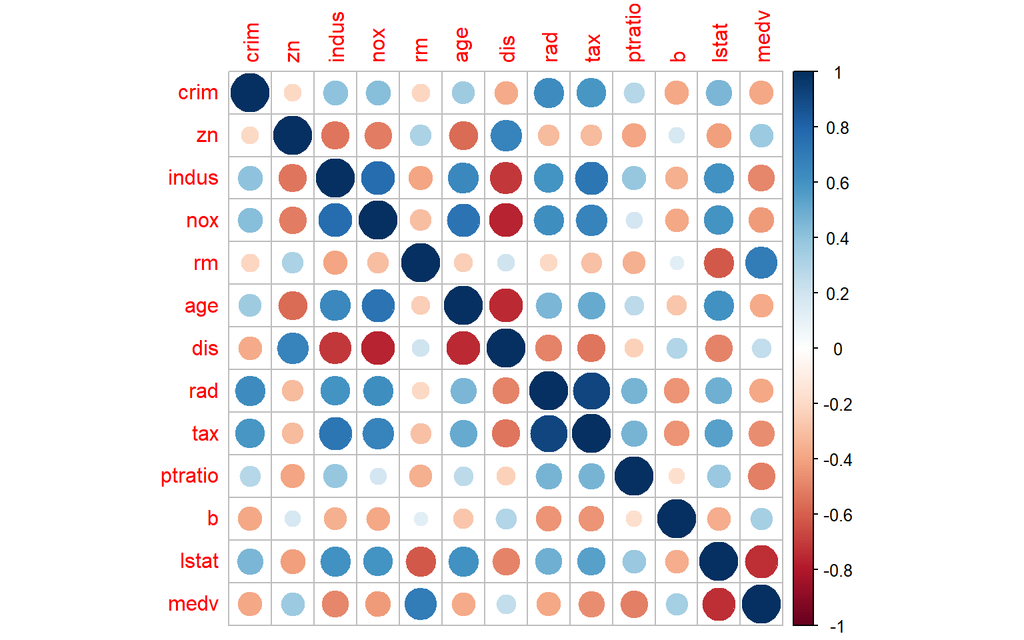

```r
set.seed(semilla)

# Correlación
correlacion<-corrplot(cor(select(datos,-chas)))
```

```r
set.seed(semilla)

# Preparación de los datos
X <- as.matrix(datos[, -14])  # Variables predictoras, excluyendo la columna 'medv'
y <- datos$medv  # Variable de respuesta
```

## División de datos

```r
set.seed(semilla)

# División de los datos en conjunto de entrenamiento y prueba
train_indices <- sample(1:nrow(X), nrow(X) * 0.8)
X_train <- X[train_indices, ]
y_train <- y[train_indices]
X_test <- X[-train_indices, ]
y_test <- y[-train_indices]
```

## Modelo Ridge

```r
set.seed(semilla)

# Modelo Ridge
ridge_model <- glmnet(X_train, y_train, alpha = 0, lambda = 0.1)
ridge_predictions <- predict(ridge_model, newx = X_test)
ridge_rmse <- sqrt(mean((ridge_predictions - y_test)^2))
print(paste("RMSE (Ridge):", ridge_rmse))
```

```
## [1] "RMSE (Ridge): 4.85058593738863"
```

## Modelo LASSO

```r
set.seed(semilla)

# Modelo Lasso
lasso_model <- glmnet(X_train, y_train, alpha = 1, lambda = 0.1)
lasso_predictions <- predict(lasso_model, newx = X_test)
lasso_rmse <- sqrt(mean((lasso_predictions - y_test)^2))
print(paste("RMSE (Lasso):", lasso_rmse))
```

```
## [1] "RMSE (Lasso): 4.86547297652402"
```

## Modelo Elastic Net

```r
set.seed(semilla)

# Modelo Elastic Net
elasticnet_model <- glmnet(X_train, y_train, alpha = 0.5, lambda = 0.1)
elasticnet_predictions <- predict(elasticnet_model, newx = X_test)
elasticnet_rmse <- sqrt(mean((elasticnet_predictions - y_test)^2))
print(paste("RMSE (Elastic Net):", elasticnet_rmse))
```

```
## [1] "RMSE (Elastic Net): 4.84453716602842"
```

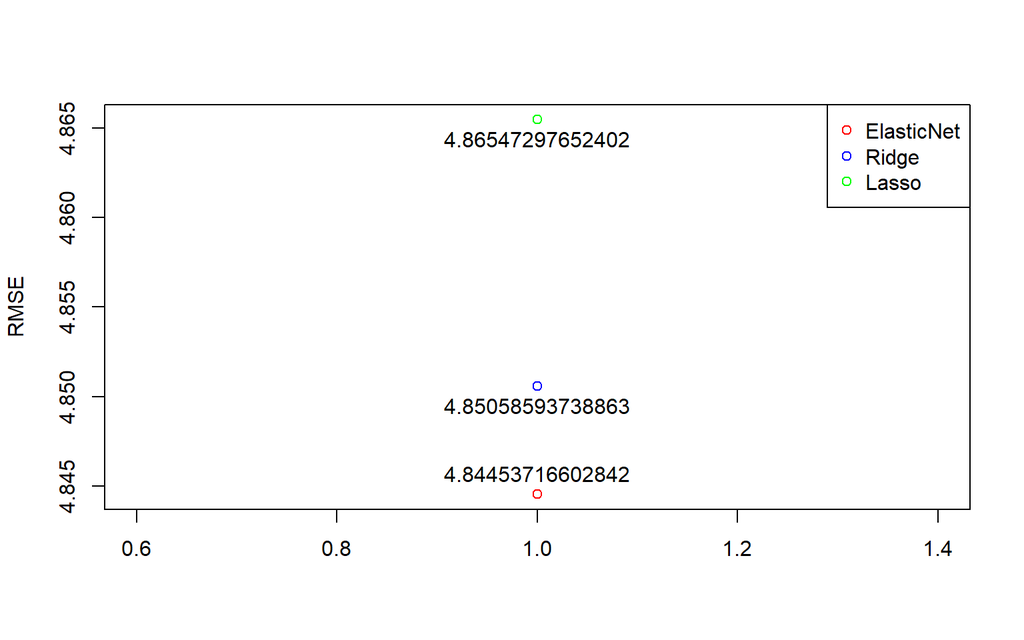

```r
set.seed(semilla)

colores <- c("red", "blue", "green")
plot(1,
     elasticnet_rmse,
     type = "b",
     col = colores[1],
     ylim = range(c(elasticnet_rmse, ridge_rmse, lasso_rmse)),
     xlab = "",
     ylab = "RMSE")

points(1, ridge_rmse, type = "b", col = colores[2])
points(1, lasso_rmse, type = "b", col = colores[3])
legend("topright",
       legend = c("ElasticNet", "Ridge", "Lasso"),
       col = colores, pch = 1)

text(1, elasticnet_rmse, labels = elasticnet_rmse, pos = 3, offset = 0.5)
text(1, ridge_rmse, labels = ridge_rmse, pos = 1, offset = 0.5)
text(1, lasso_rmse, labels = lasso_rmse, pos = 1, offset = 0.5)
```

# CO2

Dataset presente en las librerías base de R.

Consta de 84 observaciones y 5 variables.

| Variable | Descripción |
| --- | --- |
| Plant | un factor ordenado con niveles < < < … < dando un identificador único para cada planta.Qn1 Qn2 Qn3 Mc1 |
| Type | Tipo de tratamiento aplicado a las plantas, que puede ser “Quebec” o “Mississippi” |
| Treatment | Tipo de tratamiento aplicado a las plantas, que puede ser “nonchilled” (no refrigerado) o “chilled” (refrigerado) |
| conc | Concentración nominal de CO2 en partes por millón |
| uptake | Tasa de absorción de CO2 por parte de las plantas, medida en unidades de “uptake” (absorción) |

```r
set.seed(semilla)

# Carga del conjunto de datos CO2
data(CO2)
```

```r
set.seed(semilla)

# Visualizacion de datos cargados
head(CO2)
```

```
## Grouped Data: uptake ~ conc | Plant
##   Plant   Type  Treatment conc uptake
## 1   Qn1 Quebec nonchilled   95   16.0
## 2   Qn1 Quebec nonchilled  175   30.4
## 3   Qn1 Quebec nonchilled  250   34.8
## 4   Qn1 Quebec nonchilled  350   37.2
## 5   Qn1 Quebec nonchilled  500   35.3
## 6   Qn1 Quebec nonchilled  675   39.2
```

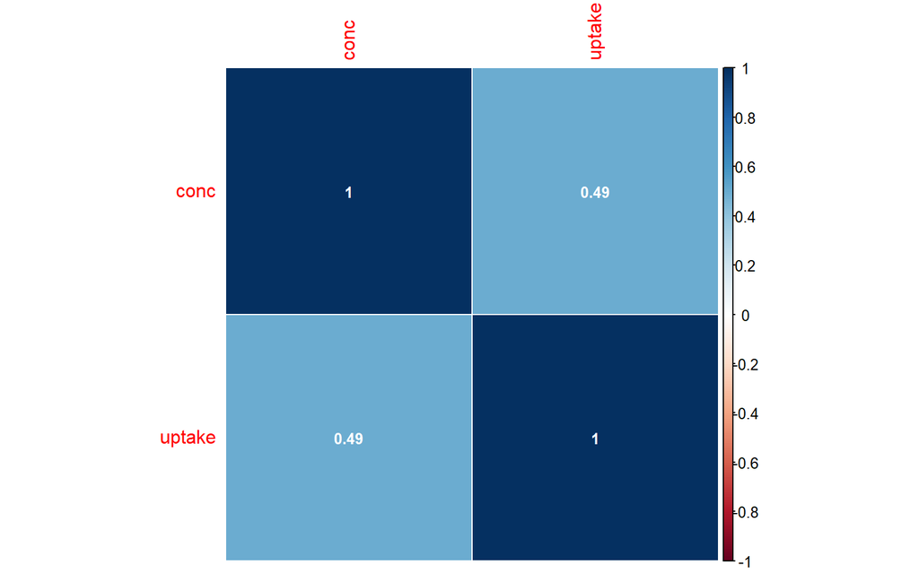

```r
set.seed(semilla)

# Correlación entre las variables númericas
mat_cor <- CO2[,c(4:5)] %>% cor(method="pearson") %>% round(digits=2)

# Mapa de calor de la correlación
corrplot(mat_cor,
         method = "color",
         addgrid.col = 'white',
         number.cex = 0.8,
         addCoef.col = "white"
         )
```

```r
set.seed(semilla)

# Agregar variables altamente correlacionadas
CO2$Variable1 <- CO2$uptake + rnorm(nrow(CO2), mean = 0, sd = 0.1)
CO2$Variable2 <- CO2$uptake + rnorm(nrow(CO2), mean = 0, sd = 0.1)
```

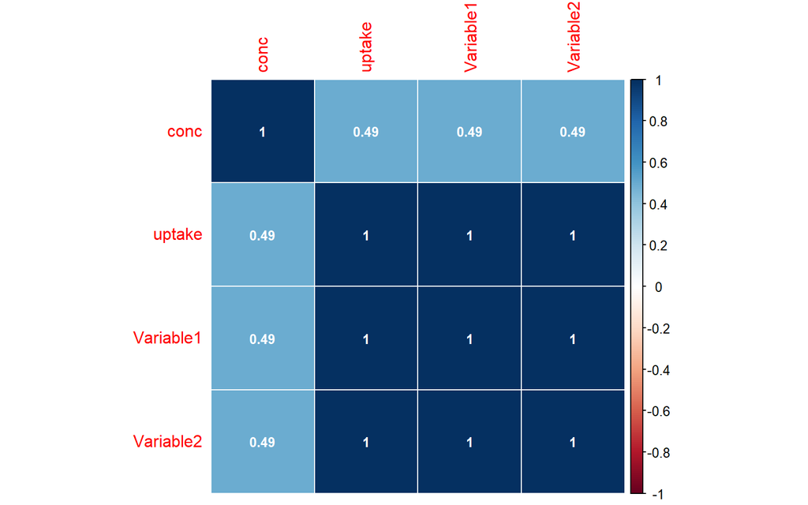

```r
set.seed(semilla)

# Correlación entre las variables númericas
mat_cor <- CO2[,c(4:7)] %>% cor(method="pearson") %>% round(digits=2)

# Mapa de calor de la correlación
corrplot(mat_cor,
         method = "color",
         addgrid.col = 'white',
         number.cex = 0.8,
         addCoef.col = "white"
         )
```

## Preparación de los datos

```r
set.seed(semilla)

# Preparación de los datos
X <- model.matrix(uptake ~ Type + Variable1 + Variable2 - 1, data = CO2)
y <- CO2$uptake
```

```r
set.seed(semilla)

# División de los datos en conjunto de entrenamiento y prueba
train_indices <- sample(1:nrow(X), nrow(X) * 0.8)
X_train <- X[train_indices, ]
y_train <- y[train_indices]
X_test <- X[-train_indices, ]
y_test <- y[-train_indices]
```

## Modelo Ridge

```r
set.seed(semilla)

# Modelo Ridge
ridge_model <- glmnet(X_train, y_train, alpha = 0, lambda = 0.1)
ridge_predictions <- predict(ridge_model, newx = X_test)
ridge_rmse <- sqrt(mean((ridge_predictions - y_test)^2))
print(paste("RMSE (Ridge):", ridge_rmse))
```

```
## [1] "RMSE (Ridge): 0.102097705152597"
```

## Modelo LASSO

```r
set.seed(semilla)

# Modelo Lasso
lasso_model <- glmnet(X_train, y_train, alpha = 1, lambda = 0.1)
lasso_predictions <- predict(lasso_model, newx = X_test)
lasso_rmse <- sqrt(mean((lasso_predictions - y_test)^2))
print(paste("RMSE (Lasso):", lasso_rmse))
```

```
## [1] "RMSE (Lasso): 0.142451559277833"
```

## Modelo Elastic Net

```r
set.seed(semilla)

# Modelo Elastic Net
elasticnet_model <- glmnet(X_train, y_train, alpha = 0.5, lambda = 0.1)
elasticnet_predictions <- predict(elasticnet_model, newx = as.matrix(X_test))
elasticnet_rmse <- sqrt(mean((elasticnet_predictions - y_test)^2))
print(paste("RMSE (Elastic Net):", elasticnet_rmse))
```

```
## [1] "RMSE (Elastic Net): 0.107977903696249"
```

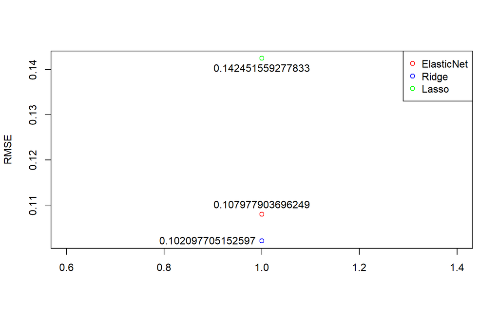

```r
set.seed(semilla)

colores <- c("red", "blue", "green")
plot(1,
     elasticnet_rmse,
     type = "b",
     col = colores[1],
     ylim = range(c(elasticnet_rmse, ridge_rmse, lasso_rmse)),
     xlab = "",
     ylab = "RMSE")

points(1, ridge_rmse, type = "b", col = colores[2])
points(1, lasso_rmse, type = "b", col = colores[3])
legend("topright",
       legend = c("ElasticNet", "Ridge", "Lasso"),
       col = colores, pch = 1)

text(1, elasticnet_rmse, labels = elasticnet_rmse, pos = 3, offset = 0.5)
text(1, ridge_rmse, labels = ridge_rmse, pos = 2, offset = 0.5)
text(1, lasso_rmse, labels = lasso_rmse, pos = 1, offset = 0.5)
```

# IOWA

Dataset presente en el uso de la librería “lasso2”.

Los datos indican las precipitaciones en la pretemporada cosecha y en los tres meses de crecimiento, las temperaturas medias en los tres meses de crecimiento y en el mes de la cosecha, el año y el rendimiento del trigo en el estado de Iowa (EE.UU.) entre 1930 y 1962.

Consta de 33 observaciones y 10 variables.

| Variable | Descripción |
| --- | --- |
| Year | Año de medición (sustituto de las mejoras varietales) |
| Rain0 | Precipitaciones de la estación (pulg.) |
| Temp1 | Temperatura media del primer mes de cultivo (grados Fahrenheit) |
| Rain1 | Precipitaciones del primer mes de cultivo (pulg.) |
| Temp2 | Temperatura media del segundo mes de cultivo (grados Fahrenheit) |
| Rain2 | Precipitaciones del segundo mes de cultivo (pulg.) |
| Temp3 | Temperatura media del tercer mes de vegetación (grados F) |
| Rain3 | Precipitaciones del tercer mes de cultivo (pulg.) |
| Temp4 | Temperatura media del mes de la cosecha (grados Fahrenheit) |
| Yield | Rendimiento del trigo en Iowa para el año en cuestión (bush./acre) |

```r
set.seed(semilla)

data(Iowa, package = "lasso2")
iowaTib <- as_tibble(Iowa)
#iowaTib <- as_tibble(data)
iowaTib
```

```
## # A tibble: 33 × 10
##     Year Rain0 Temp1 Rain1 Temp2 Rain2 Temp3 Rain3 Temp4 Yield
##    <int> <dbl> <dbl> <dbl> <dbl> <dbl> <dbl> <dbl> <dbl> <dbl>
##  1  1930  17.8  60.2  5.83  69    1.49  77.9  2.42  74.4  34
##  2  1931  14.8  57.5  3.83  75    2.72  77.2  3.3   72.6  32.9
##  3  1932  28.0  62.3  5.17  72    3.12  75.8  7.1   72.2  43
##  4  1933  16.8  60.5  1.64  77.8  3.45  76.4  3.01  70.5  40
##  5  1934  11.4  69.5  3.49  77.2  3.85  79.7  2.84  73.4  23
##  6  1935  22.7  55    7     65.9  3.35  79.4  2.42  73.6  38.4
##  7  1936  17.9  66.2  2.85  70.1  0.51  83.4  3.48  79.2  20
##  8  1937  23.3  61.8  3.8   69    2.63  75.9  3.99  77.8  44.6
##  9  1938  18.5  59.5  4.67  69.2  4.24  76.5  3.82  75.7  46.3
## 10  1939  18.6  66.4  5.32  71.4  3.15  76.2  4.72  70.7  52.2
## # ℹ 23 more rows
```

```r
set.seed(semilla)

#Cantidad de valores nulos
sum(is.na(iowaTib))
```

```
## [1] 0
```

```r
set.seed(semilla)

#Ubicacion de los valores nulos en las columnas
sapply(iowaTib, function(x)sum(is.na(x)))
```

```
##  Year Rain0 Temp1 Rain1 Temp2 Rain2 Temp3 Rain3 Temp4 Yield
##     0     0     0     0     0     0     0     0     0     0
```

Vista de datos

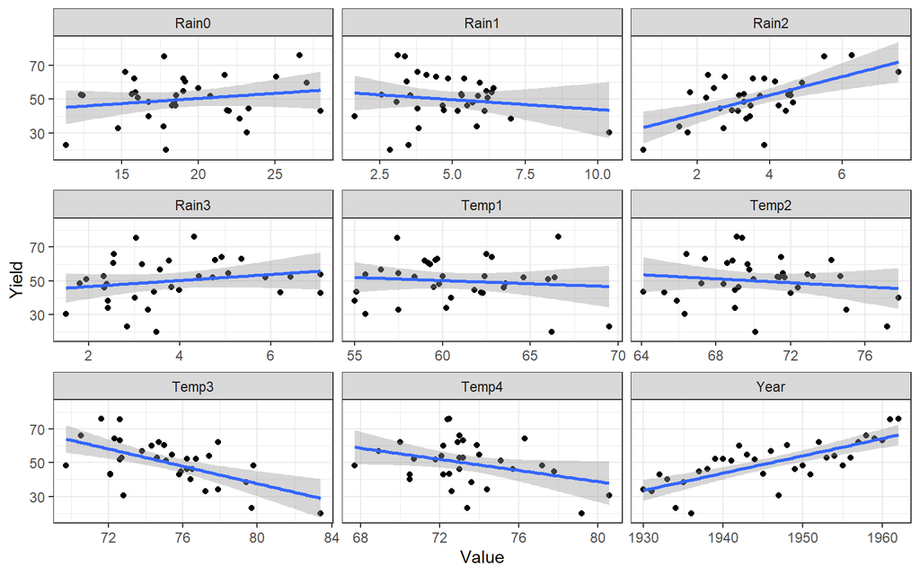

```r
set.seed(semilla)

iowaUntidy <- gather(iowaTib, "Variable", "Value", -Yield)
ggplot(iowaUntidy, aes(Value, Yield)) +
  facet_wrap(~ Variable, scales = "free_x") +
  geom_point() +
  geom_smooth(method = "lm") +
  theme_bw()
```

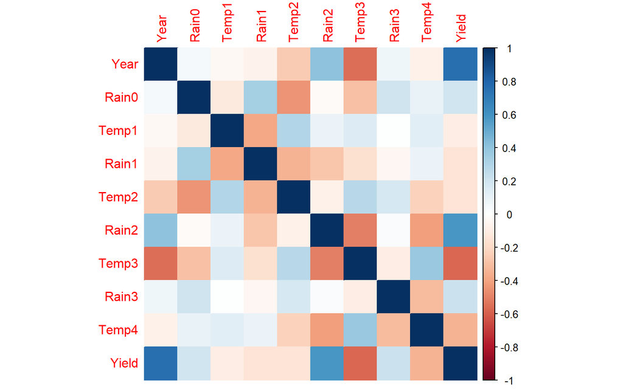

```r
set.seed(semilla)

# Correlación entre las variables númericas
mat_cor <- Iowa %>% cor(method="pearson") %>% round(digits=2)

# Mapa de calor de la correlación
corrplot(mat_cor,
         method = "color")
```

## Ridge

```r
iowaTask <- makeRegrTask(data = iowaTib, target = "Yield")
ridge <- makeLearner("regr.glmnet", alpha = 0, id = "ridge")
```

### Visualización de Datos Filtrados

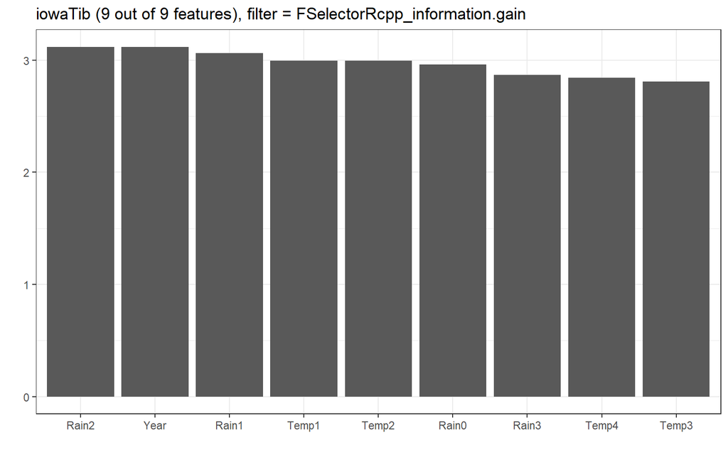

```r
set.seed(semilla)

filterVals <- generateFilterValuesData(iowaTask)
plotFilterValues(filterVals) +
  theme_bw()
```

### Mejorando hiperparámetros lambda (s)

```r
set.seed(semilla)

ridgeParamSpace <- makeParamSet(
  makeNumericParam("s", lower = 0, upper = 15))

randSearch <- makeTuneControlRandom(maxit = 200)
cvForTuning <- makeResampleDesc("RepCV", folds = 3, reps = 10)


parallelStartSocket(cpus = detectCores())
```

```
## Starting parallelization in mode=socket with cpus=4.
```

```r
tunedRidgePars <- tuneParams(ridge, task = iowaTask,
                             resampling = cvForTuning,
                             par.set = ridgeParamSpace,
                             control = randSearch)
```

```
## [Tune] Started tuning learner ridge for parameter set:
```

```
##      Type len Def  Constr Req Tunable Trafo
## s numeric   -   - 0 to 15   -    TRUE     -
```

```
## With control class: TuneControlRandom
```

```
## Imputation value: Inf
```

```
## Exporting objects to slaves for mode socket: .mlr.slave.options
```

```
## Mapping in parallel: mode = socket; level = mlr.tuneParams; cpus = 4; elements = 200.
```

```
## [Tune] Result: s=7.6 : mse.test.mean=102.4407617
```

```r
parallelStop()
```

```
## Stopped parallelization. All cleaned up.
```

```r
tunedRidgePars
```

```
## Tune result:
## Op. pars: s=7.6
## mse.test.mean=102.4407617
```

### Visualización de los hiperparametros ajustados

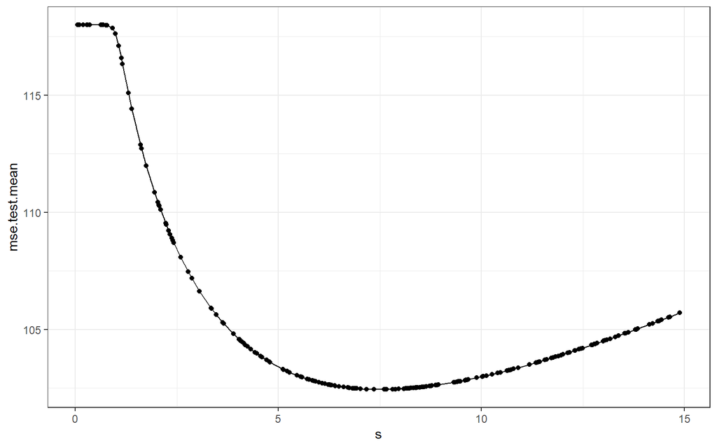

```r
set.seed(semilla)

ridgeTuningData <- generateHyperParsEffectData(tunedRidgePars)
plotHyperParsEffect(ridgeTuningData,
                    x = "s",
                    y = "mse.test.mean",
                    plot.type = "line") +
  theme_bw()
```

### Entrenamiento con Ridge usando los parametros de lambda ajustados

```r
set.seed(semilla)

tunedRidge <- setHyperPars(ridge, par.vals = tunedRidgePars$x)
tunedRidgeModel <- train(tunedRidge, iowaTask)
```

### Coeficientes del modelo

```r
set.seed(semilla)

ridgeModelData <- getLearnerModel(tunedRidgeModel)
ridgeCoefs <- coef(ridgeModelData, s = tunedRidgePars$x$s)
ridgeCoefs
```

```
## 10 x 1 sparse Matrix of class "dgCMatrix"
##                        s1
## (Intercept) -8.280343e+02
## Year         4.924844e-01
## Rain0        3.067955e-01
## Temp1       -2.115123e-01
## Rain1       -6.596001e-01
## Temp2        1.770402e-04
## Rain2        1.837302e+00
## Temp3       -6.008846e-01
## Rain3        6.254199e-01
## Temp4       -4.626438e-01
```

### Visualización de coeficientes

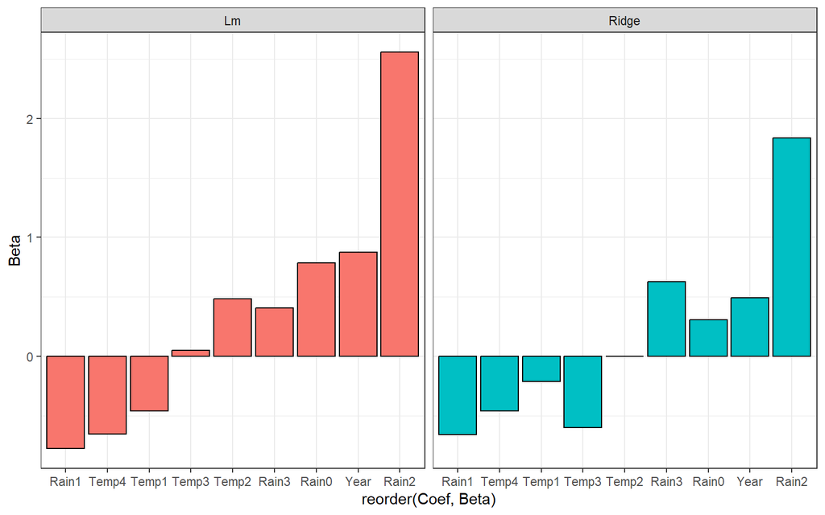

```r
set.seed(semilla)

lmCoefs <- coef(lm(Yield ~ ., data = iowaTib))

coefTib <- tibble(Coef = rownames(ridgeCoefs)[-1],
                  Ridge = as.vector(ridgeCoefs)[-1],
                  Lm = as.vector(lmCoefs)[-1]
)

coefUntidy <- gather(coefTib, key = Model, value = Beta, -Coef)
ggplot(coefUntidy, aes(reorder(Coef, Beta), Beta, fill = Model)) +
  geom_bar(stat = "identity", col = "black") +
  facet_wrap(~Model) +
  theme_bw() +
  theme(legend.position = "none")
```

## LASSO

```r
set.seed(semilla)

lasso <- makeLearner("regr.glmnet", alpha = 1, id = "lasso")
```

### Ajuste de parámetros lambda de LASSO

```r
set.seed(semilla)

lassoParamSpace <- makeParamSet(
makeNumericParam("s", lower = 0, upper = 15))
parallelStartSocket(cpus = detectCores())
```

```
## Starting parallelization in mode=socket with cpus=4.
```

```r
tunedLassoPars <- tuneParams(lasso, task = iowaTask,
resampling = cvForTuning,
par.set = lassoParamSpace,
control = randSearch)
```

```
## [Tune] Started tuning learner lasso for parameter set:
```

```
##      Type len Def  Constr Req Tunable Trafo
## s numeric   -   - 0 to 15   -    TRUE     -
```

```
## With control class: TuneControlRandom
```

```
## Imputation value: Inf
```

```
## Exporting objects to slaves for mode socket: .mlr.slave.options
```

```
## Mapping in parallel: mode = socket; level = mlr.tuneParams; cpus = 4; elements = 200.
```

```
## [Tune] Result: s=2.1 : mse.test.mean=92.1062441
```

```r
parallelStop()
```

```
## Stopped parallelization. All cleaned up.
```

```r
tunedLassoPars
```

```
## Tune result:
## Op. pars: s=2.1
## mse.test.mean=92.1062441
```

### Visualización de hiperparametros ajustados

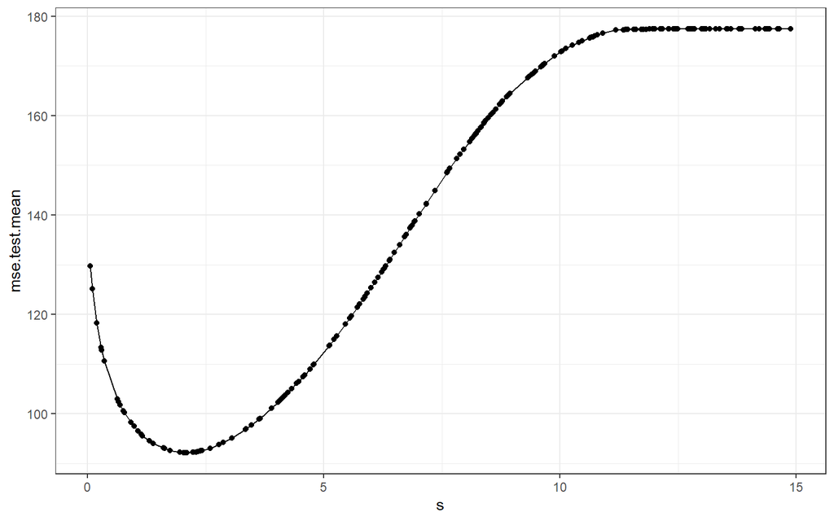

```r
set.seed(semilla)

lassoTuningData <- generateHyperParsEffectData(tunedLassoPars)
plotHyperParsEffect(lassoTuningData,
                    x = "s",
                    y = "mse.test.mean",
                    plot.type = "line") +
  theme_bw()
```

### Entrenamiento con LASSO usando los parametros de lambda ajustados

```r
set.seed(semilla)

tunedLasso <- setHyperPars(lasso, par.vals = tunedLassoPars$x)
tunedLassoModel <- train(tunedLasso, iowaTask)
```

### Coeficientes del modelo LASSO

```r
set.seed(semilla)

lassoModelData <- getLearnerModel(tunedLassoModel)
lassoCoefs <- coef(lassoModelData, s = tunedLassoPars$x$s)
lassoCoefs
```

```
## 10 x 1 sparse Matrix of class "dgCMatrix"
##                        s1
## (Intercept) -1.232426e+03
## Year         6.710846e-01
## Rain0        2.566006e-02
## Temp1        .
## Rain1        .
## Temp2        .
## Rain2        1.717000e+00
## Temp3       -1.508748e-01
## Rain3        .
## Temp4       -2.558561e-01
```

### Visualización de parametros

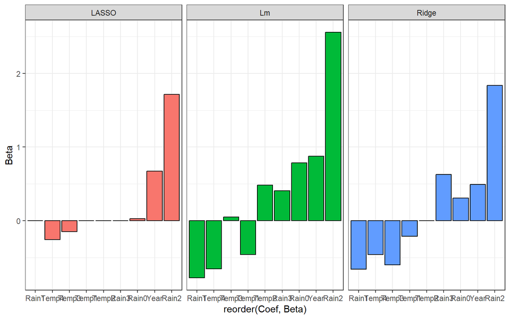

```r
set.seed(semilla)

coefTib$LASSO <- as.vector(lassoCoefs)[-1]
coefUntidy <- gather(coefTib, key = Model, value = Beta, -Coef)

ggplot(coefUntidy, aes(reorder(Coef, Beta), Beta, fill = Model)) +
  geom_bar(stat = "identity", col = "black") +
  facet_wrap(~ Model) +
  theme_bw() +
  theme(legend.position = "none")
```

## Elastic Net

```r
set.seed(semilla)

# Modelo Entrenamiento Elastic Net
elastic <- makeLearner("regr.glmnet", id = "elastic")
```

### Ajuste de lambda y alpha

```r
set.seed(semilla)

elasticParamSpace <- makeParamSet(
makeNumericParam("s", lower = 0, upper = 10),
makeNumericParam("alpha", lower = 0, upper = 1))

randSearchElastic <- makeTuneControlRandom(maxit = 400)
parallelStartSocket(cpus = detectCores())
```

```
## Starting parallelization in mode=socket with cpus=4.
```

```r
tunedElasticPars <- tuneParams(elastic, task = iowaTask,
                               resampling = cvForTuning,
                               par.set = elasticParamSpace,
                               control = randSearchElastic)
```

```
## [Tune] Started tuning learner elastic for parameter set:
```

```
##          Type len Def  Constr Req Tunable Trafo
## s     numeric   -   - 0 to 10   -    TRUE     -
## alpha numeric   -   -  0 to 1   -    TRUE     -
```

```
## With control class: TuneControlRandom
```

```
## Imputation value: Inf
```

```
## Exporting objects to slaves for mode socket: .mlr.slave.options
```

```
## Mapping in parallel: mode = socket; level = mlr.tuneParams; cpus = 4; elements = 400.
```

```
## [Tune] Result: s=2.32; alpha=0.932 : mse.test.mean=92.3708041
```

```r
parallelStop()
```

```
## Stopped parallelization. All cleaned up.
```

```r
tunedElasticPars
```

```
## Tune result:
## Op. pars: s=2.32; alpha=0.932
## mse.test.mean=92.3708041
```

### Visualización de parametros ajustados

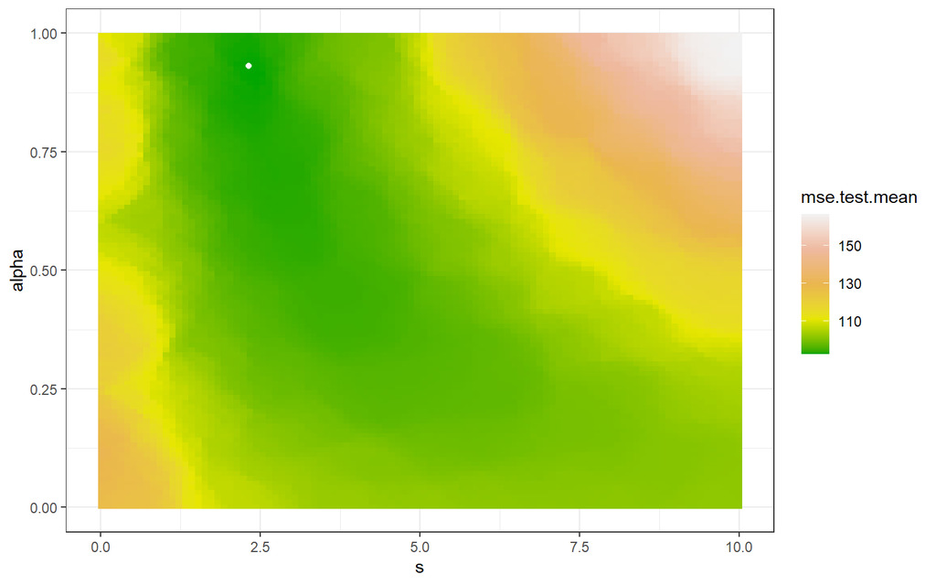

### Entrenamiento con hiperparametros ajustados

```r
set.seed(semilla)

tunedElastic <- setHyperPars(elastic, par.vals = tunedElasticPars$x)
tunedElasticModel <- train(tunedElastic, iowaTask)
```

## Coeficientes de los modelos

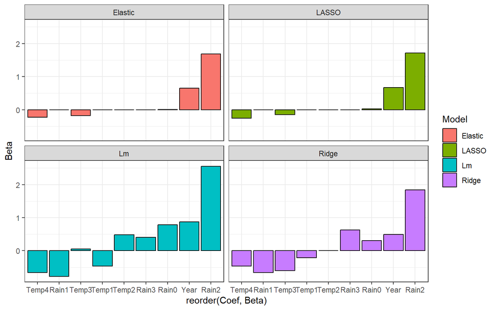

```r
set.seed(semilla)

elasticModelData <- getLearnerModel(tunedElasticModel)
elasticCoefs <- coef(elasticModelData, s = tunedElasticPars$x$s)
coefTib$Elastic <- as.vector(elasticCoefs)[-1]

coefUntidy <- gather(coefTib, key = Model, value = Beta, -Coef)
ggplot(coefUntidy, aes(reorder(Coef, Beta), Beta, fill = Model)) +
  geom_bar(stat = "identity", position = "dodge", col = "black") +
  facet_wrap(~ Model) +
  theme_bw()
```

```r
set.seed(semilla)

ridgeWrapper <- makeTuneWrapper(ridge, resampling = cvForTuning,
par.set = ridgeParamSpace,
control = randSearch)
lassoWrapper <- makeTuneWrapper(lasso,
                                resampling = cvForTuning,
                                par.set = lassoParamSpace,
                                control = randSearch)
elasticWrapper <- makeTuneWrapper(elastic,
                                  resampling = cvForTuning,
                                  par.set = elasticParamSpace,
                                  control = randSearchElastic)
learners = list(ridgeWrapper, lassoWrapper, elasticWrapper, "regr.lm")
```

## Valores de los modelos

```r
set.seed(semilla)

kFold3 <- makeResampleDesc("CV", iters = 3)
parallelStartSocket(cpus = detectCores())
```

```
## Starting parallelization in mode=socket with cpus=4.
```

```r
bench <- benchmark(learners, iowaTask, kFold3)
```

```
## Exporting objects to slaves for mode socket: .mlr.slave.options
```

```
## Mapping in parallel: mode = socket; level = mlr.benchmark; cpus = 4; elements = 4.
```

```r
parallelStop()
```

```
## Stopped parallelization. All cleaned up.
```

```r
bench
```

```
##   task.id    learner.id mse.test.mean
## 1 iowaTib   ridge.tuned     100.22461
## 2 iowaTib   lasso.tuned      85.63437
## 3 iowaTib elastic.tuned      93.56668
## 4 iowaTib       regr.lm     149.70058
```

## Grafica de modelos

- Ridge

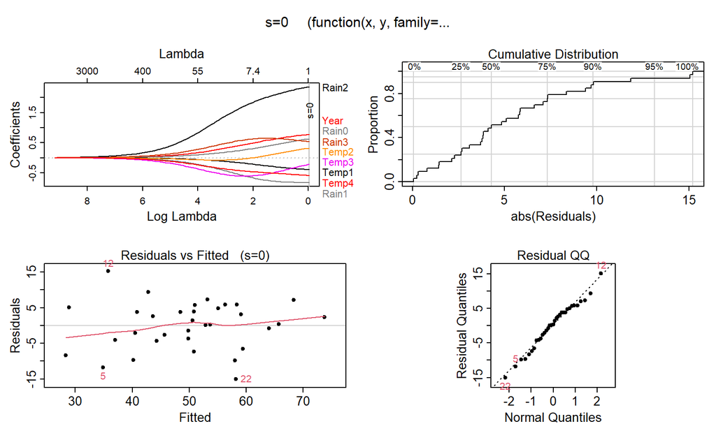

```r
set.seed(semilla)

start_time <- Sys.time()  # Registra el tiempo de inicio
plotres(ridgeModelData)
```

```r
end_time <- Sys.time()  # Registra el tiempo de finalización
execution_time <- end_time - start_time  # Calcula el tiempo de ejecución
print(execution_time)  # Imprime el tiempo de ejecución
```

```
## Time difference of 0.69594 secs
```

- Lasso

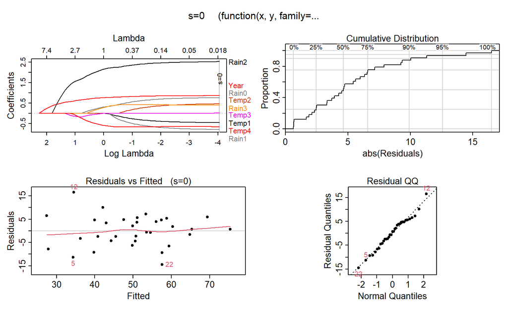

```r
set.seed(semilla)

start_time <- Sys.time()  # Registra el tiempo de inicio
plotres(lassoModelData)
```

```r
end_time <- Sys.time()  # Registra el tiempo de finalización
execution_time <- end_time - start_time  # Calcula el tiempo de ejecución
print(execution_time)  # Imprime el tiempo de ejecución
```

```
## Time difference of 0.6611812 secs
```

- Elastic Net

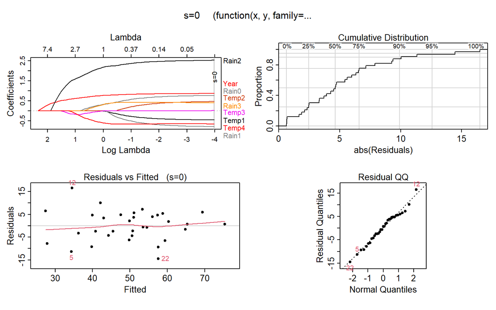

```r
set.seed(semilla)

start_time <- Sys.time()  # Registra el tiempo de inicio
plotres(elasticModelData)
```

```r
end_time <- Sys.time()  # Registra el tiempo de finalización
execution_time <- end_time - start_time  # Calcula el tiempo de ejecución
print(execution_time)  # Imprime el tiempo de ejecución
```

```
## Time difference of 1.090525 secs
```